# Reproducible Research: Peer Assessment 1

Jim Pfleger

This report analyzes data from a personal activity monitoring device, which collected the number of steps taken at 5 minute intervals through out the day. The data consists of two months of data from an anonymous individual collected during the months of October and November 2012.

The data set can be downloaded from https://d396qusza40orc.cloudfront.net/repdata%2Fdata%2Factivity.zip and contains these variables:

- **steps**: Number of steps taking in a 5-minute interval (missing values are coded as NA)
- **date**: The date on which the measurement was taken in YYYY-MM-DD format
- **interval**: Identifier for the 5-minute interval in which measurement was taken

The dataset consists of 17,568 observations in a comma-separated-value (CSV) file.

## Loading and preprocessing the data

### Retrieve and unzip data file

If the data file is not already unzipped, unzip it. If there is no file to unzip, retrieve it from the original URL.

```r
datafile <- 'activity.csv'
if (!file.exists(datafile)) {
  zip <- 'activity.zip'
  if (!file.exists(zip)) {
    download.file('https://d396qusza40orc.cloudfront.net/repdata%2Fdata%2Factivity.zip', zip, method = 'libcurl')
  }
  unzip(zip)
}
```

### Tidy data

Read the CSV file and clean up the data types.

```r
library(lubridate)
steps.raw <- read.csv(datafile)
steps.raw$date <- ymd(steps.raw$date)
steps.raw$interval <- factor(steps.raw$interval)
```

## What is mean total number of steps taken per day?

### Summarize by day

Sum the steps taken per day into a new data frame, ignoring any missing values.

```r
library(dplyr, quietly = TRUE, warn.conflicts = FALSE)
steps.daily <- steps.raw %>% group_by(date) %>% summarize(steps = sum(steps))
```

### Histogram of daily steps

Plot a histogram of the new summary data frame.

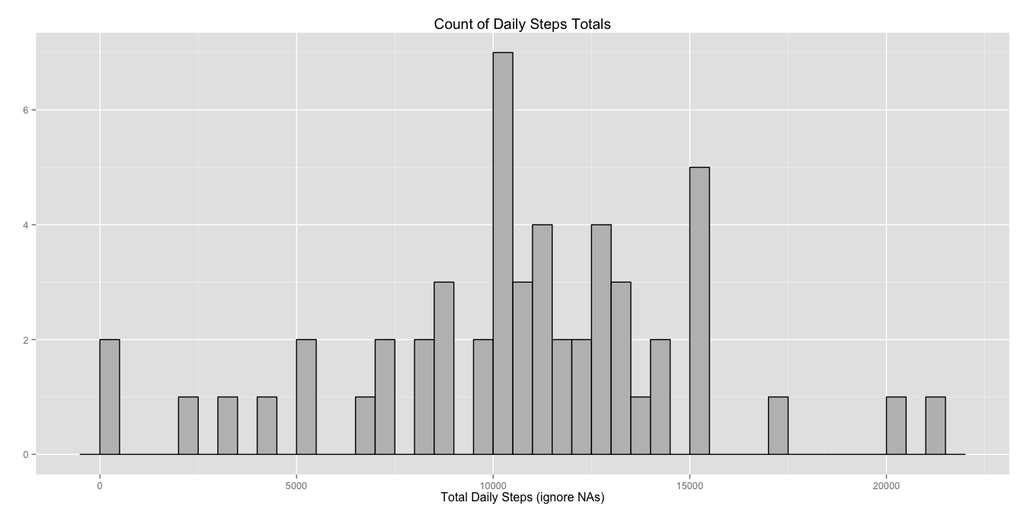

```r
library(ggplot2)
g <- ggplot(steps.daily, aes(x = steps))
g <- g + geom_histogram(binwidth=500, color = 'black', fill = 'gray')
g <- g + labs(title = 'Count of Daily Steps Totals',
              x = 'Total Daily Steps (ignore NAs)',
              y = '')
g
```

### Summary statistics for daily steps

Produce summary statistics for the daily steps data frame.

```r
daily.mean <- mean(steps.daily$steps, na.rm = TRUE)
daily.median <- median(steps.daily$steps, na.rm = TRUE)
summary <- rbind(c(daily.mean, daily.median))
rownames(summary) <- c('Daily')
colnames(summary) <- c('Mean', 'Median')
summary
```

```
##           Mean Median
## Daily 10766.19  10765
```

## What is the average daily activity pattern?

### Summarize by interval

```r
library(dplyr, quietly = TRUE, warn.conflicts = FALSE)
steps.interval <- steps.raw %>% group_by(interval) %>% summarize(steps = mean(steps, na.rm = TRUE))
```

### Line chart of steps by interval

Create a line chart of the new summary data frame.

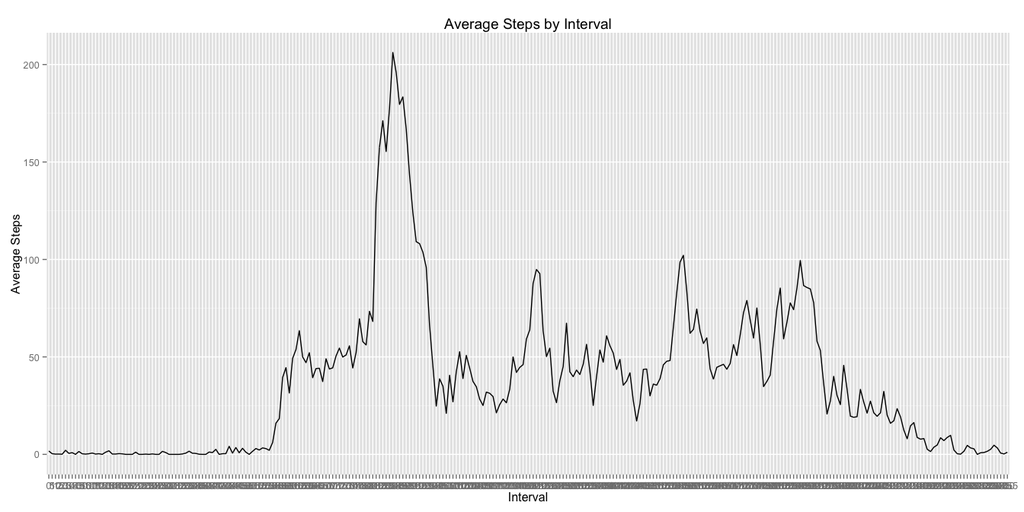

```r
library(ggplot2)
g <- ggplot(steps.interval, aes(x = interval, y = steps, group = NA))
g <- g + geom_line()
g <- g + labs(title = 'Average Steps by Interval',
              x = 'Interval',
              y = 'Average Steps')
g
```

## Impute missing values

Create a new data frame of raw steps but replace any missing step values with the mean for that interval.

```r
library(dplyr, quietly = TRUE, warn.conflicts = FALSE)
steps.imputed <- merge(steps.raw, steps.interval, by = c('interval'))
NAs <- is.na(steps.imputed$steps.x)
steps.imputed[NAs,]$steps.x <- steps.imputed[NAs,]$steps.y
steps.imputed <- select(steps.imputed, interval = interval, steps = steps.x, date = date)
```

### Summarize by day (including imputed)

Sum the steps taken per day into a new data frame, but include the imputed data.

```r
library(dplyr, quietly = TRUE, warn.conflicts = FALSE)
steps.daily.imputed <- steps.imputed %>% group_by(date) %>% summarize(steps = sum(steps))
```

### Histogram of daily steps (including imputed)

Plot a histogram of the new imputed summary data frame.

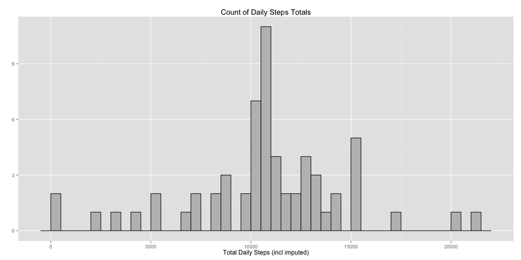

```r
library(ggplot2)
g <- ggplot(steps.daily.imputed, aes(x = steps))
g <- g + geom_histogram(binwidth=500, color = 'black', fill = 'gray')
g <- g + labs(title = 'Count of Daily Steps Totals',
              x = 'Total Daily Steps (incl imputed)',
              y = '')
g
```

### Summary statistics for daily steps (including imputed)

Produce summary statistics for the imputed daily steps data frame and compare them to the non-imputed summary statistics.

```r
daily.mean.imputed <- mean(steps.daily.imputed$steps)
daily.median.imputed <- median(steps.daily.imputed$steps)
summary <- rbind(c(daily.mean, daily.median), c(daily.mean.imputed, daily.median.imputed))
rownames(summary) <- c('Daily (raw)', 'Daily (imputed)')
colnames(summary) <- c('Mean', 'Median')
summary
```

```
##                     Mean   Median
## Daily (raw)     10766.19 10765.00
## Daily (imputed) 10766.19 10766.19
```

The daily mean is unchanged because the NAs were replaced with the interval means. However, the median is slightly larger.

## Are there differences in activity patterns between weekdays and weekends?

### Determine weekdays and weekends

Use a modulo trick to quickly determine whether the date is a weekday. `wday()` returns 1 for Sunday and 7 for Saturday. Subtracting one changes these to 0 and 6 respectively. Now when dividing by 6 the remainder will be 0 for Sunday and Saturday and non-zero for all other days.

```r
library(lubridate)
steps.imputed$daytype <- (wday(steps.imputed$date) - 1) %% 6 == 0
steps.imputed$daytype <- factor(steps.imputed$daytype, labels = c('weekday', 'weekend'))
```

### Summarize by interval per daytype (including imputed)

Produce a new summary data frame of the mean steps per interval, with regard to daytype.

```r
library(dplyr, quietly = TRUE, warn.conflicts = FALSE)
steps.daytype.imputed <- steps.imputed %>% group_by(daytype, interval) %>% summarize(steps = mean(steps))
```

### Line chart of steps per interval by daytype (including imputed)

Plot a pair of line charts showing the mean steps per interval for weekdays and weekends.

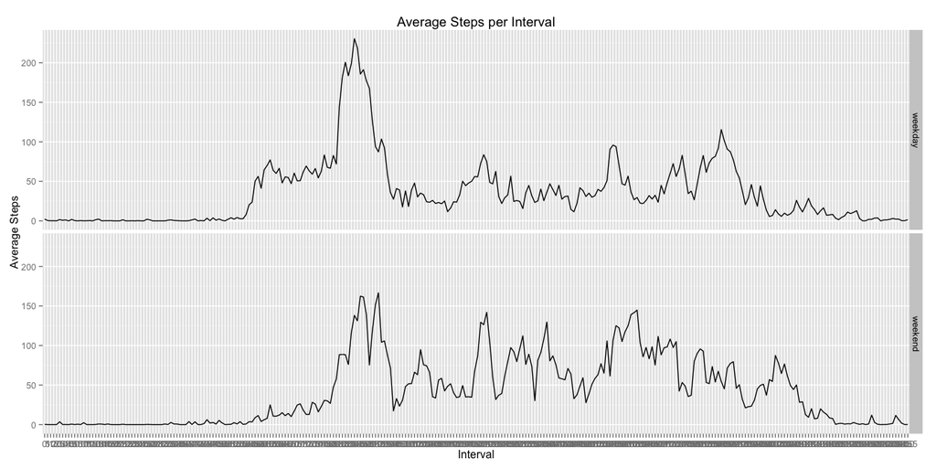

```r
library(ggplot2)
g <- ggplot(steps.daytype.imputed, aes(x = interval, y = steps, group = NA))
g <- g + facet_grid(daytype ~ .)
g <- g + geom_line()
g <- g + labs(title = 'Average Steps per Interval',
              x = 'Interval',
              y = 'Average Steps')
g
```

**Note:** Although it seems redundant, each R chunk includes statements to load its libraries so the chunk can be run on its own in R Studio.